# BCB420 Assignment 2 Differential Gene Expression & Thresholded over-representation analysis

Kuai Yu

# Introduction

In this notebook, I am going to perform differential gene expression analysis and overrepresentation analysis on noramlized data from assignment 1. The original data is RNAseq raw counts. The controls are MCF7 cells transfected with control siRNA and the tests are MCF7 cells transfected with ESR1 siRNAs (SmartPool) and RECQ1 siRNAs (SmartPool) for 48 hours (Lu et al. 2021). In the original paper, they perform gene expression analysis and overrepresentation analysis on ESR1 vs control and RECQ1 vs control to study relation between RECQ1 and ESR1. Also, they are interested in finding relation between RECQ1 and breast cancer.

# Initial Setup

## check package is installed

```r
if (!requireNamespace("ComplexHeatmap", quietly = TRUE))
  BiocManager::install("ComplexHeatmap")
if (!requireNamespace("circlize", quietly = TRUE))
  install.packages("circlize")
if (!requireNamespace("gprofiler2", quietly = TRUE))
  install.packages("gprofiler2")
if (!requireNamespace("kableExtra", quietly = TRUE))
  install.packages("kableExtra")
```

## Load package

```r
library(edgeR)
library(circlize)
library(ComplexHeatmap)
library(gprofiler2)
library(kableExtra)
```

## Load data

Please modify the normalized_count_data_path since the file in github is in another location

```r
# Read data from assignment 1

normalized_count_data_path <- "./final_counts.csv"

# Please modify the datapath
normalized_count_data <- read.table(normalized_count_data_path,
                                    header = TRUE,
                                    sep = ",",
                                    stringsAsFactors = FALSE,
                                    check.names = FALSE)

# Find missing column names for hgnc_symbol
colnames(normalized_count_data)[1] <- "hgnc_symbol"

# Make a martix from normalized data
data_matrix <- normalized_count_data[3: ncol(normalized_count_data)]
rownames(data_matrix) <- normalized_count_data$hgnc_symbol
colnames(data_matrix) <- colnames(normalized_count_data[3: ncol(normalized_count_data)])
```

```r
# Group them based on different cell types
cell_type <- unlist(strsplit(colnames(normalized_count_data[3: ncol(normalized_count_data)]), "_"))[c(FALSE, TRUE, FALSE)]
samples <- data.frame(cell_type = cell_type)
rownames(samples) <- colnames(normalized_count_data[3: ncol(normalized_count_data)])
```

```r
# Define model
classes <- samples$cell_type
model_design <- model.matrix(~0 + classes )
```

# Differential Gene Expression

In the original paper, author conducts two differential Gene Expression analysis, one is RecQ1 vs CTL, the other is ESR1 vs CTL. Here, I am going to conduct these two differential Gene Expression analysis. I use Quasi liklihood model for differential expression analysis since it is recommended for bulk rna-seq data and my data is in negative bionomial distribution.

```r
contrast_RecQ1CTL <- makeContrasts(
  RecQ1CTL ="classessiRecQ1-classessiCTL",
  levels=model_design)

contrast_ESR1 <- makeContrasts(
  ESR1CTL ="classessiESR1-classessiCTL",
  levels=model_design)
```

## Differential Gene Expression between RecQ1 knockdown and control

First, differential Gene Expression analysis of RecQ1 vs CTL will be conducted first

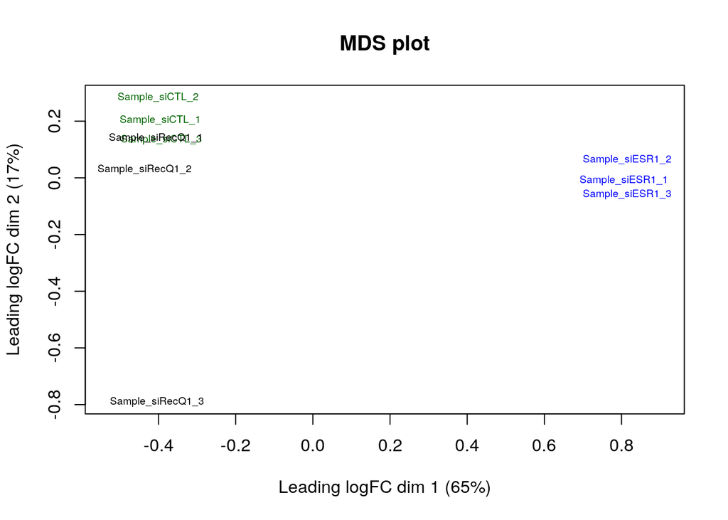

```r
d = DGEList(counts=data_matrix, group=samples$cell_type)
plotMDS(d, labels=rownames(samples),
 col = c("darkgreen","blue")[factor(samples$cell_type)], cex = 0.6, main = "MDS plot")
```

```r
d <- estimateDisp(d, model_design)
fit <- glmQLFit(d, model_design)
qlf.RecQ1CTL <- glmQLFTest(fit,
                        contrast = contrast_RecQ1CTL
                        )
```

### Multiple hypothesis testing

For every gene, I correct them using Benjamini-Hochberg (Benjamini and Hochberg 1995), also known as fdr. I use this method because it is a powerful tool that decreases the false discovery rate and it is a common method for multiple hypothesis testing.

```r
# adjust methods
qlf_output_hits_RecQ1CTL <- topTags(qlf.RecQ1CTL,
                           sort.by = "PValue",
                           n = nrow(normalized_count_data),
                           adjust.method = "BH")
```

### threshold

After that, I used cutoff of 0.05 for pvalue and fdr. This is because pvalue < 0.05 is statistically significant and it is a commonly used statistic threshold.

```r
length(which(qlf_output_hits_RecQ1CTL$table$PValue < 0.05))
```

```
## [1] 553
```

```r
length(which(qlf_output_hits_RecQ1CTL$table$FDR < 0.05))
```

```
## [1] 46
```

### HeatMap

I use HeatMap to visualize the expression. From the result, we can see samples from each conditions cluster and the difference in expression is very apparent.

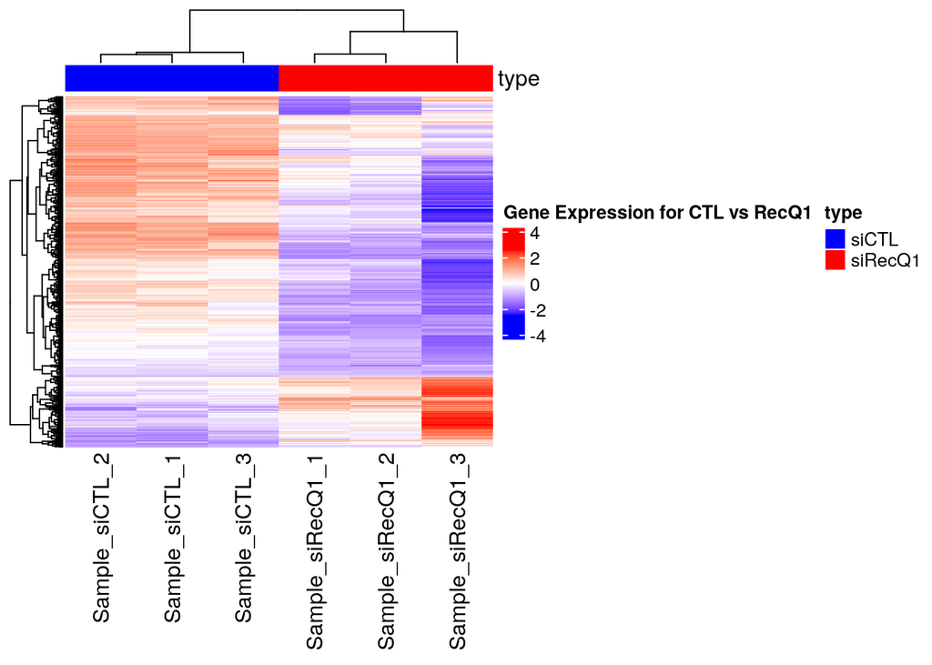

```r
top_hits <- rownames(qlf_output_hits_RecQ1CTL$table)[
 qlf_output_hits_RecQ1CTL$table$PValue < 0.05]
heatmap_matrix_tophits <- t(
 scale(t(data_matrix[which(rownames(data_matrix)
 %in% top_hits),])))
heatmap_matrix_tophits <- heatmap_matrix_tophits[,! colnames(heatmap_matrix_tophits) %in% c("Sample_siESR1_3",  "Sample_siESR1_1", "Sample_siESR1_2")]
if(min(heatmap_matrix_tophits) == 0){
  heatmap_col = colorRamp2(c( 0, max(heatmap_matrix_tophits)),
                           c( "white", "red"))
} else {
  heatmap_col = colorRamp2(c(min(heatmap_matrix_tophits), 0,
                             max(heatmap_matrix_tophits)),
                           c("blue", "white", "red"))
}


ha_colours <- c("blue","red")
siCTLsiRecQ1classes <- unique(classes)
siCTLsiRecQ1classes <- siCTLsiRecQ1classes[siCTLsiRecQ1classes != "siESR1"]
names(ha_colours) <- unique(siCTLsiRecQ1classes)
ha <- HeatmapAnnotation(df=data.frame(
  type = classes[classes != "siESR1"]),
  col = list(type = ha_colours))

current_heatmap <- Heatmap(as.matrix(heatmap_matrix_tophits),
                           cluster_rows = TRUE,
                           cluster_columns = TRUE,
                           show_row_dend = TRUE,
                           show_column_dend = TRUE,
                           col = heatmap_col,
                           show_column_names = TRUE,
                           show_row_names = FALSE,
                           show_heatmap_legend = TRUE,
                           top_annotation = ha,
                           name = "Gene Expression for CTL vs RecQ1"
                          )
plot(current_heatmap)
```

### Volcano Plot

I use volcano plot to visualize amount of differentially expressed genes. We can see that most of them are downregulated genes

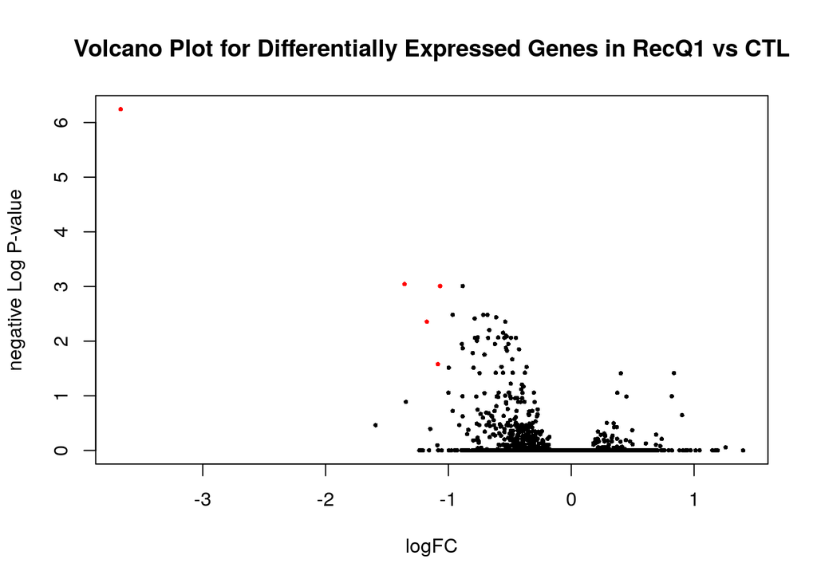

```r
volcano_data <- cbind(qlf_output_hits_RecQ1CTL$table$logFC, -log10(qlf_output_hits_RecQ1CTL$table$FDR))
colnames(volcano_data) <- c("logFC", "negative Log P-value")
degs <- qlf_output_hits_RecQ1CTL$table$FDR < 0.05 & abs(qlf_output_hits_RecQ1CTL$table$logFC) > 1
point.col <- ifelse(degs, "red", "black")
plot(volcano_data,
     pch = 16,
     col = point.col,
     cex = 0.5,
     main = "Volcano Plot for Differentially Expressed Genes in RecQ1 vs CTL")
```

## Differential Gene Expression between ESR1 knockdown and control

### Multiple hypothesis testing

```r
qlf.ESR1CTL <- glmQLFTest(fit,
                        contrast = contrast_ESR1
                        )

qlf_output_hits_ESR1CTL <- topTags(qlf.ESR1CTL,
                           sort.by = "PValue",
                           n = nrow(normalized_count_data),
                           adjust.method = "BH")
```

### Threshold

```r
length(which(qlf_output_hits_ESR1CTL$table$PValue < 0.05))
```

```
## [1] 2284
```

```r
length(which(qlf_output_hits_ESR1CTL$table$FDR < 0.05))
```

```
## [1] 1160
```

### Heatmap

I use HeatMap to visualize the expression . From the result, we can see samples from each conditions cluster and the difference in expression is even more apparent than the one in RECQ1 vs CTL.

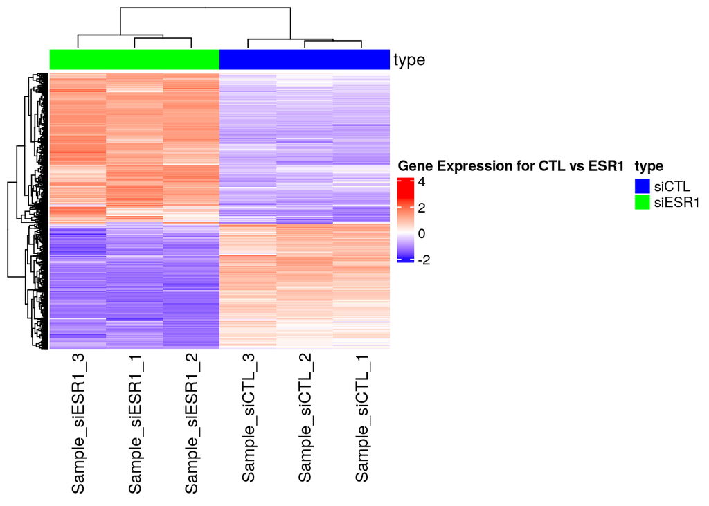

```r
top_hits <- rownames(qlf_output_hits_ESR1CTL$table)[
 qlf_output_hits_ESR1CTL$table$PValue < 0.05]
heatmap_matrix_tophits <- t(
 scale(t(data_matrix[which(rownames(data_matrix)
 %in% top_hits),])))
heatmap_matrix_tophits <- heatmap_matrix_tophits[,! colnames(heatmap_matrix_tophits) %in% c("Sample_siRecQ1_3",  "Sample_siRecQ1_1", "Sample_siRecQ1_2")]
if(min(heatmap_matrix_tophits) == 0){
  heatmap_col = colorRamp2(c( 0, max(heatmap_matrix_tophits)),
                           c( "white", "red"))
} else {
  heatmap_col = colorRamp2(c(min(heatmap_matrix_tophits), 0,
                             max(heatmap_matrix_tophits)),
                           c("blue", "white", "red"))
}


ha_colours <- c("green","blue")
siCTLsiESR1classes <- unique(classes)
siCTLsiESR1classes <- siCTLsiESR1classes[siCTLsiESR1classes != "siRecQ1"]
names(ha_colours) <- unique(siCTLsiESR1classes)
ha <- HeatmapAnnotation(df=data.frame(
  type = classes[classes != "siRecQ1"]),
  col = list(type = ha_colours))

current_heatmap <- Heatmap(as.matrix(heatmap_matrix_tophits),
                           cluster_rows = TRUE,
                           cluster_columns = TRUE,
                           show_row_dend = TRUE,
                           show_column_dend = TRUE,
                           col = heatmap_col,
                           show_column_names = TRUE,
                           show_row_names = FALSE,
                           show_heatmap_legend = TRUE,
                           top_annotation = ha,
                           name = "Gene Expression for CTL vs ESR1")
plot(current_heatmap)
```

### Volano plot

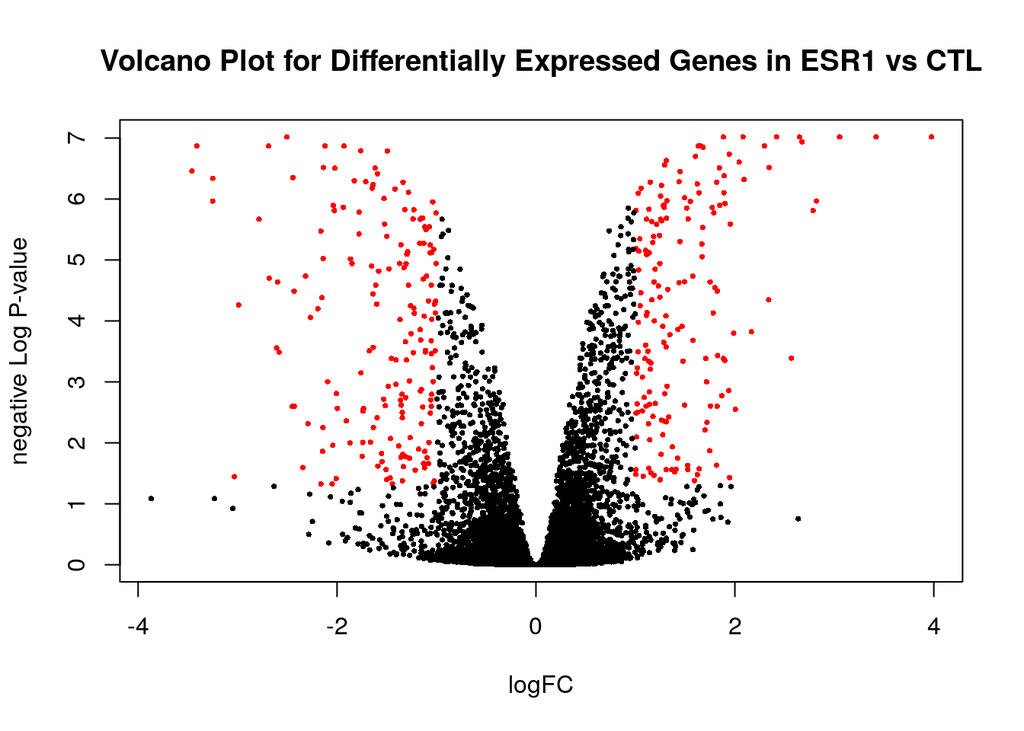

```r
volcano_data <- cbind(qlf_output_hits_ESR1CTL$table$logFC, -log10(qlf_output_hits_ESR1CTL$table$FDR))
colnames(volcano_data) <- c("logFC", "negative Log P-value")
degs <- qlf_output_hits_ESR1CTL$table$FDR < 0.05 & abs(qlf_output_hits_ESR1CTL$table$logFC) > 1
point.col <- ifelse(degs, "red", "black")
plot(volcano_data,
     pch = 16,
     col = point.col,
     cex = 0.5,
     main = "Volcano Plot for Differentially Expressed Genes in ESR1 vs CTL")
```

## Prepare gene_list for Thresholded over-representation analysis

```r
RecQ1CTL_top <- qlf_output_hits_RecQ1CTL$table[which(qlf_output_hits_RecQ1CTL$table$PValue < 0.05),]
RecQ1CTL_gene_list <- rownames(qlf_output_hits_RecQ1CTL$table[which(qlf_output_hits_RecQ1CTL$table$PValue < 0.05),])

ESR1CTL_top <- qlf_output_hits_ESR1CTL$table[which(qlf_output_hits_ESR1CTL$table$PValue < 0.05),]
ESR1CTL_gene_list <- rownames(qlf_output_hits_ESR1CTL$table[which(qlf_output_hits_ESR1CTL$table$PValue < 0.05),])
```

# Thresholded over-representation analysis

For Thresholded over-representation analysis, I am going to use g:Profiler (Reimand et al. 2016). I use this tool because it is easy to use and incorporate many annotation data. I am going to use gprofiler2, the R client of gprofiler to conduct enrichment analysis.

The data source that I used are “Reactome”(Fabregat et al. 2018) and “WikiPathways”(Martens et al. 2021). I used these data source because I am looking for some specific pathways associated with ESR1, estrogen and breast cancer. Data source like GO:BP, GO:MF (Consortium 2004) contains molecular-level activities, which do not suits my needs. According to G:Profiler, the version of WikiPathways is 20211210 and Reactome is annotations: BioMart classes: 2022-1-3

## Thresholded over-representation analysis for RecQ1 vs CTL

First, I will run g:Profiler for RecQ1 vs CTL with the all differentially expressed genes together and the up-regulated and down regulated differentially expressed genes separately

### All differentially expressed genes together

Run gprofiler with parameters of correction method of FDR threshold of 0.05, Then I get 35 significant pathways

```r
RecQ1CTL_gostres <- gost(query = RecQ1CTL_gene_list,
                organism = "hsapiens",
                correction_method = "fdr",
                user_threshold = 0.05,
                sources = c("REAC", "WP"))

RecQ1CTL_enrichment_result <- RecQ1CTL_gostres$result
RecQ1CTL_enrichment_result <- RecQ1CTL_enrichment_result[RecQ1CTL_enrichment_result$term_size < 500, ]
nrow(RecQ1CTL_enrichment_result)
```

```
## [1] 35
```

In the enrichment result, we can see Extra-nuclear estrogen signaling and ESR-mediated signaling are significantly expressed marked in yellow. Thus, knock-down of RECQ1 correlates with expression of estrogen signaling and ESR.

```r
elements <-  c("precision", "recall", "term_id", "source", "term_name")
kable(RecQ1CTL_enrichment_result[RecQ1CTL_enrichment_result$source == "REAC", elements][1: 10, ],
      type = "html",
      caption = "Table 1. Reactome Genesets for all genes in RECQ1 vs CTL") %>%
  row_spec(c(1, 7), background = "yellow")
```

Table 1. Reactome Genesets for all genes in RECQ1 vs CTL

|  | precision | recall | term_id | source | term_name |
| --- | --- | --- | --- | --- | --- |
| 4 | 0.0319767 | 0.1506849 | REAC:R-HSA-9009391 | REAC | Extra-nuclear estrogen signaling |
| 5 | 0.0319767 | 0.1486486 | REAC:R-HSA-9013106 | REAC | RHOC GTPase cycle |
| 6 | 0.0901163 | 0.0698198 | REAC:R-HSA-9012999 | REAC | RHO GTPase cycle |
| 7 | 0.0377907 | 0.1181818 | REAC:R-HSA-6785807 | REAC | Interleukin-4 and Interleukin-13 signaling |
| 8 | 0.0290698 | 0.1428571 | REAC:R-HSA-9013026 | REAC | RHOB GTPase cycle |
| 9 | 0.0668605 | 0.0790378 | REAC:R-HSA-9006931 | REAC | Signaling by Nuclear Receptors |
| 10 | 0.0552326 | 0.0875576 | REAC:R-HSA-8939211 | REAC | ESR-mediated signaling |
| 11 | 0.0290698 | 0.1388889 | REAC:R-HSA-199992 | REAC | trans-Golgi Network Vesicle Budding |
| 12 | 0.0319767 | 0.1250000 | REAC:R-HSA-9013404 | REAC | RAC2 GTPase cycle |
| 13 | 0.0174419 | 0.2307692 | REAC:R-HSA-1538133 | REAC | G0 and Early G1 |

```r
kable(RecQ1CTL_enrichment_result[RecQ1CTL_enrichment_result$source == "WP", elements][1:15,],
      format = "html",
      caption = "Table 2. WikiPathways Genesets for all genes in RECQ1 vs CTL") %>%
  row_spec(c(5, 15), background = "yellow")
```

Table 2. WikiPathways Genesets for all genes in RECQ1 vs CTL

|  | precision | recall | term_id | source | term_name |
| --- | --- | --- | --- | --- | --- |
| 21 | 0.0474453 | 0.1477273 | WP:WP2446 | WP | Retinoblastoma gene in cancer |
| 22 | 0.0218978 | 0.3750000 | WP:WP3969 | WP | H19 action Rb-E2F1 signaling and CDK-Beta-catenin activity |
| 23 | 0.0620438 | 0.1042945 | WP:WP437 | WP | EGF/EGFR signaling pathway |
| 24 | 0.0510949 | 0.1228070 | WP:WP4659 | WP | Gastrin signaling pathway |
| 25 | 0.0255474 | 0.2121212 | WP:WP2817 | WP | Mammary gland development pathway - Pregnancy and lactation (Stage 3 of 4) |
| 26 | 0.0401460 | 0.1309524 | WP:WP4806 | WP | EGFR tyrosine kinase inhibitor resistance |
| 27 | 0.0510949 | 0.1052632 | WP:WP366 | WP | TGF-beta signaling pathway |
| 28 | 0.0218978 | 0.2307692 | WP:WP3658 | WP | Wnt/beta-catenin signaling pathway in leukemia |
| 29 | 0.0437956 | 0.1111111 | WP:WP615 | WP | Senescence and autophagy in cancer |
| 30 | 0.0328467 | 0.1323529 | WP:WP2032 | WP | Thyroid stimulating hormone (TSH) signaling pathway |
| 31 | 0.0328467 | 0.1323529 | WP:WP1403 | WP | AMP-activated protein kinase (AMPK) signaling |
| 32 | 0.0291971 | 0.1481481 | WP:WP2864 | WP | Apoptosis-related network due to altered Notch3 in ovarian cancer |
| 33 | 0.0255474 | 0.1707317 | WP:WP2828 | WP | Bladder cancer |
| 34 | 0.1058394 | 0.0663616 | WP:WP3888 | WP | VEGFA-VEGFR2 signaling pathway |
| 35 | 0.0145985 | 0.3076923 | WP:WP2814 | WP | Mammary gland development pathway - Puberty (Stage 2 of 4) |